# A2_Antonio_Rolda_Andrade

Antonio Roldán Andrade

2025-11-10

# 1 Esperanza de Vida

## 1.1 Análisis Descriptivo

Previo al estudio del caso realizo las transformaciones de las columnas para mejor legibilidad.

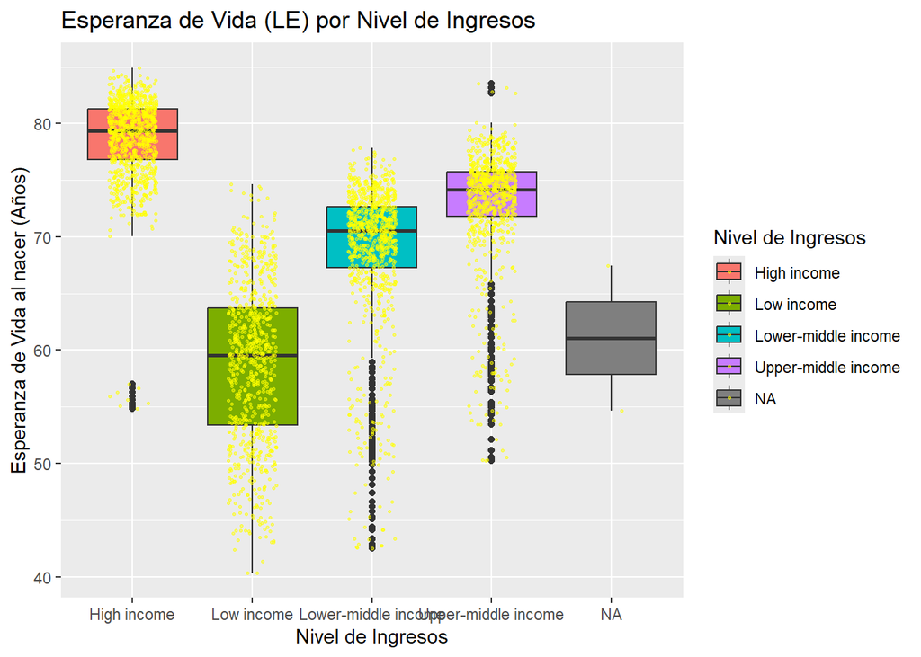

```r
# Antes de comenzar abrimos el dataset
xlsx_location <- "WorldSustainabilityDS_clean.xlsx"
worldSustainabiltyDataSet <- read_excel(xlsx_location)

# Pasamos ahora a renombrar SP.DYN.LE00.IN
worldSustainabiltyDataSet <- worldSustainabiltyDataSet %>%
  rename(LE = `SP.DYN.LE00.IN`)
# Extraemos las columnas necesarias {LE,Income, Region}

dtLEInReg <- worldSustainabiltyDataSet %>% select(LE, Income,Region)

# Grafico comparando Esperanza de vida y nivel de ingresos

grafico1_1 <- ggplot(
  data = dtLEInReg,
  mapping = aes(x = Income, y = LE, fill = Income) # Con fill mostramos por color cada grupo de Income
) +
  geom_boxplot() +
  geom_jitter(
    color = "yellow",
    size = 0.5,
    alpha = 0.5, # Transparencia para evitar superposición
    width = 0.2  # Pequeño desplazamiento horizontal para los puntos
  ) +
  labs(
    title = "Esperanza de Vida (LE) por Nivel de Ingresos",
    x = "Nivel de Ingresos",
    y = "Esperanza de Vida al nacer (Años)",
    fill = "Nivel de Ingresos"
  )
# Mostrar el gráfico
print(grafico1_1)
```

```r
names(worldSustainabiltyDataSet)
```

```
##  [1] "Country"              "CountryCode"          "Year"
##  [4] "EG.ELC.ACCS.ZS"       "NY.ADJ.NNTY.PC.KD.ZG" "NY.ADJ.SVNX.GN.ZS"
##  [7] "NY.ADJ.DCO2.GN.ZS"    "NY.ADJ.DRES.GN.ZS"    "NY.ADJ.DFOR.GN.ZS"
## [10] "NY.ADJ.DPEM.GN.ZS"    "FB.ATM.TOTL.P5"       "FM.LBL.BMNY.GD.ZS"
## [13] "SE.PRM.UNER.ZS"       "SE.COM.DURS"          "IC.REG.COST.PC.FE.ZS"
## [16] "IC.REG.COST.PC.MA.ZS" "NE.EXP.GNFS.ZS"       "NE.CON.TOTL.ZS"
## [19] "NY.GDP.MKTP.CD"       "NY.GDP.PCAP.CD"       "NE.CON.GOVT.ZS"
## [22] "NE.DAB.TOTL.ZS"       "NY.GNS.ICTR.ZS"       "NE.IMP.GNFS.ZS"
## [25] "FP.CPI.TOTL.ZG"       "SE.PRM.CMPT.ZS"       "SG.GEN.PARL.ZS"
## [28] "SE.PRM.ENRL.TC.ZS"    "EG.ELC.RNEW.ZS"       "EG.FEC.RNEW.ZS"
## [31] "SE.PRE.ENRR"          "SE.PRM.ENRR"          "SE.SEC.ENRR"
## [34] "NE.TRD.GNFS.ZS"       "SG.LAW.INDX"          "SN_ITK_DEFC"
## [37] "SI_POV_DAY1"          "IT_MOB_2GNTWK"        "IT_MOB_3GNTWK"
## [40] "SP_ACS_BSRVH2O"       "SL_TLF_UEM_M"         "SL_TLF_UEM_F"
## [43] "GH.EM.IC.LUF"         "Continent"            "SI.POV.GINI"
## [46] "Income"               "IT.NET.USER.ZS"       "LE"
## [49] "SP.POP.TOTL"          "Regime"               "SP.RUR.TOTL.ZS"
## [52] "NY.GDP.TOTL.RT.ZS"    "SP.URB.TOTL.IN.ZS"    "Region"
```

## 1.2 Hipótesis

- La pregunta a contrastar es: ¿La esperanza de vida es mayor en los países con alto nivel de ingresos que en el resto?
- Los datos a usar son los pertenencientes a países con ingresos altos (High Income) del último año de los datos (2018)

Por tanto, podemos plantear las siguientes hipótesis:

- u1 -> LE High Income
- u2 -> LE Resto
- H0: u1 = u2
- H1: u1 > u2

Realizaremos un test unilateral derecho para verificar la hipótesis nula.

## 1.3 Test

Estamos en un caso en el que se tiene una muestra de datos grandes por lo que se puede asumir que la distribución sigue una distribución normal, puesto que la población es mayor que 30. Además tratamos de un contraste de hipótesis de dos poblaciones (High Income y el resto) independientes sin varianza conocida.

```r
# Realizamos un filtrado extrayendo los datos que necesitamos

# LE de altos ingresos
dt1_3 <- worldSustainabiltyDataSet %>%
  filter(Year == 2018)

# Preparamos la columnas como True o false en caso de High Income o no
dt1_3 <- dt1_3 %>%
  filter(!is.na(LE)) %>% # No usamos las columnas con NA
  # 2. Guardamos el resultado de mutate en IncomeGroup
  mutate(
    IncomeGroup = case_when(
      # Si el ingreso es 'High income', asigna 'Alto Ingreso'
      Income == "High income" ~ "Alto Ingreso",
      # Para cualquier otro caso (el resto de ingresos), asigna 'Resto de Ingresos'
      TRUE ~ "Resto Ingresos"
    )
  )

# Realizamos antes de asumir nada sobre las varianzas si estas son iguales
alpha <- 1 - 0.95
m1 <- mean(dt1_3$LE[dt1_3$IncomeGroup == 'Alto Ingreso'])
m2 <- mean(dt1_3$LE[dt1_3$IncomeGroup == 'Resto Ingresos'])
n1 <- length(dt1_3$LE[dt1_3$IncomeGroup == 'Alto Ingreso'])
n2 <- length(dt1_3$LE[dt1_3$IncomeGroup == 'Resto Ingresos'])
s1 <- sd(dt1_3$LE[dt1_3$IncomeGroup == 'Alto Ingreso'])
s2 <- sd(dt1_3$LE[dt1_3$IncomeGroup == 'Resto Ingresos'])
fobs <- (s1*s1)/(s2*s2)

fcritL <- qf(alpha/2, df1 = n1-1, df2= n2-1)
fcritU <- qf(1 - alpha/2, df1 = n1-1, df2= n2-1)

# Calculamos el pvalue
pvalue <- min(
  pf(fobs, df1=n1-1, df2=n2-2, lower.tail = FALSE),
  pf(fobs, df1=n1-1, df2=n2-2)
)

c(fobs, fcritL, fcritU, pvalue)
```

```
## [1] 2.310280e-01 6.149601e-01 1.558094e+00 2.063459e-08
```

Como podemos apreciar se rechaza la hipótesis nula, tanto por caer fuera del intervalo de confianza como por el valor de pvalue. Por tanto, las varianzas son distintas.

## 1.4 Aplicación del Test Estadístico

```r
# Aplicamos t student

t.test(dt1_3$LE[dt1_3$IncomeGroup == 'Alto Ingreso'], dt1_3$LE[dt1_3$IncomeGroup == 'Resto Ingresos'], alternative="greater", var.equal=FALSE)
```

```
##
##  Welch Two Sample t-test
##
## data:  dt1_3$LE[dt1_3$IncomeGroup == "Alto Ingreso"] and dt1_3$LE[dt1_3$IncomeGroup == "Resto Ingresos"]
## t = 13.668, df = 169.76, p-value < 2.2e-16
## alternative hypothesis: true difference in means is greater than 0
## 95 percent confidence interval:
##  9.018434      Inf
## sample estimates:
## mean of x mean of y
##  79.96936  69.70942
```

## 1.5 Desarrollo

Dada la situación en la que nos encontramos (varianza desconocida, poblaciones distintas y no dependientes) tendremos que realizar los siguientes cálculos:

```r
# Calculamos el test T de Welch

tWelch <- (m1 - m2) / sqrt( (s1^2/n1) + ( s2^2/n2 ) )

# Calculamos los grados de libertad df

df_num <- ( ( s1^2/n1 ) + (s2^2/n2) )^2
df_den <- ( (s1^2/n1)^2 / (n1-1) ) + ( (s2^2/n2)^2 / (n2-1) )
df <- df_num / df_den
# Calculamos el pvalue ==> Queremos comprobar que sea mayor, por lo que unilateral derecho
# Reuso la variable
pvalue <- pt(tWelch, df=df, lower.tail = FALSE)
```

## 1.6 Resultados

```
## --- Resultados de la Prueba T de Welch (Implementación Propia) ---
```

```
## Media (µ1) Alto Ingreso: 79.9694
```

```
## Media (µ2) Resto Ingresos: 69.7094
```

```
## Valor Observado (Estadístico t): 13.668
```

```
## Grados de Libertad (df): 169.76
```

```
## [1] "Valor p (unilateral, H1: µ1 > µ2):"
```

```
## [1] 1.84478e-29
```

## 1.7 Interpretación

Como podemos apreciar el valor calculado es muy similar al obtenido al usar la función que nos proporciona el entorno de R, por lo que podemos decir con una fiabilidad del 95 % que la hipotesis nula no se cumple, por lo que la hipotesis alternativa será tomada como correcta, por tanto, podemos afirmar que la esperanza de vida en países con alto ingresos es superior a la de países con menores ingresos.

# 2 Desigualdad a lo largo del tiempo

**PR2: ¿La desigualdad se reduce en un período de 10 años?**

```r
# Preparamos los datos:
# Usamos la columna SI.POV.GINI ==> renombramos a GINI
# Rango de tiempo ==> 2008 a 2018
# Población 1: Todos los países del mundo.
# Población 2: Países de cuya región == “Europe and Northern America”

dt2 <- worldSustainabiltyDataSet %>% rename( GINI = SI.POV.GINI )
worldSustainabiltyDataSet <- worldSustainabiltyDataSet %>% rename( GINI = SI.POV.GINI )

dt2 <- dt2 %>% filter( (Year >= 2008 ) & (Year <=2018 ) )

#Filtramos y preordenados
dt2EuNorthern <- dt2 %>%
  filter(Region == "Europe and Northern America") %>%
  arrange(desc(GINI))

dt2 <- dt2 %>% arrange(desc(GINI)) # Ordenamos todos los paises
```